# Controlling contaminants in 16S rRNA gene sequencing experiments with decontam

Lisa Karstens

## Introduction

We recently performed a study to understand the impact of decreasing microbial biomass on 16S rRNA gene sequencing experiments and evaluate the current computational strategies to control for contaminants (preprint available here).

Here, we provide the compiled R Markdown document to reproduce the analysis presented in the manuscript, divided into 6 primary sections:

- [Introduction and evaluating contaminants](https://lakarstens.github.io/ControllingContaminants16S/Analyses/ControllingContaminants16S.html)
- [Removing contaminant ASVs with filtering methods](https://lakarstens.github.io/ControllingContaminants16S/Analyses/ControllingContaminants16S_Filtering.html)
- Removing contaminant ASVs with decontam (this document)
- [Removing contaminant ASVs with SourceTracker](https://lakarstens.github.io/ControllingContaminants16S/Analyses/ControllingContaminants16S_SourceTrackerPrep.html)
- [Evaluating SourceTracker results](https://lakarstens.github.io/ControllingContaminants16S/Analyses/ControllingContaminants16S_SourceTracker.html)
- [Final evaluation of all methods](https://lakarstens.github.io/ControllingContaminants16S/Analyses/ControllingContaminantsResults.html)

For more information about the experimental design and preprocessing of the data, see the **Introduction and evaluating contaminants** section.

## Remove contaminant ASVs with decontam

Decontam is an R package developed specifically to identify and remove contaminants from 16S rRNA gene sequencing experiments using a simple statistical approach. See the preprint [here](https://www.biorxiv.org/content/early/2017/11/17/221499) and tutorials [here](https://benjjneb.github.io/decontam/).

Decontam implements two primary approaches for identifying contaminants. The first approach is a *frequency* approach which identifies significant inverse correlations between ASV abundance and DNA concentration measured **prior** to library prep. The second approach is *prevalence* approach which identifies ASVs that appear more often (are more prevalent) in blank control samples than in experimental samples. There are also many combinations available for using information from both of these approaches (see the decontam website for more details).

Since we only have one blank control sample, we cannot evaluate the prevalence approach and instead focus on the *frequency* approach. We measured DNA concentration with nanodrop prior to library preparation and these values are stored in the phyloseq object’s sample data as “DNA_conc”.

This document assumes that you have read **Introduction and evaluating contaminants** and have the data file from running that section.

### Set up the workspace

This analysis uses freely available open source packages that are available on CRAN and Bioconductor.

To run this analysis yourself, download the supplemental material here along with the R markdown file.

```r
# load libraries
library(ggplot2)
library(tidyverse)
library(RColorBrewer)
library(reshape2)
library(phyloseq)
library(decontam); packageVersion("decontam")
```

```
## [1] '1.1.2'
```

```r
library(knitr)
options(digits=2)
library(kableExtra)
library(gridExtra)
# save session info (packages versions loaded)
session <- sessionInfo()

# load data from running the 'Controlling contaminants 16S' R Markdown file
load('mockDilutionsPrep.RData')
```

Running decontam is straightforward. We will use the isContaminant function from decontam, which requires:

- a phyloseq object or data table with the abundances of each ASV (or OTU) in each sample
- the method to be used (in this case frequency)
- the threshold for determining if an ASV is a contaminant or not
- the name of the column from the sample data that contains the DNA concentration.

We will store the results of decontam in and object called **contam.freq**:

```r
# Evaluate different thresholds of decontam
contam.freq <- isContaminant(mock_ps, method="frequency", threshold=0.1, conc="DNA_conc")
```

All of these values can be reviewed by viewing the contam.freq data frame. Here we will create a temporary data frame with shortened rownames for viewing since our rownames are the ASV sequences and are quite long (making viewing difficult).

```r
## Create a temporary copy of contam.freq with shorter rownames for easy display
temp_contam.freq <- contam.freq

# change the rownames to something managable
rownames(temp_contam.freq) <- paste0("SV",seq(nrow(temp_contam.freq)))

# display the first 10 rows of the data frame
print(head(temp_contam.freq))
```

```
##      freq prev p.freq p.prev    p contaminant
## SV1 0.193    9   0.98     NA 0.98       FALSE
## SV2 0.153    9   0.99     NA 0.99       FALSE
## SV3 0.111    9   0.97     NA 0.97       FALSE
## SV4 0.113    9   0.99     NA 0.99       FALSE
## SV5 0.058    9   0.97     NA 0.97       FALSE
## SV6 0.045    9   1.00     NA 1.00       FALSE
```

It is also possible to plot the abundance of individual ASVs by DNA concentration with the **plot_frequency** function in decontam:

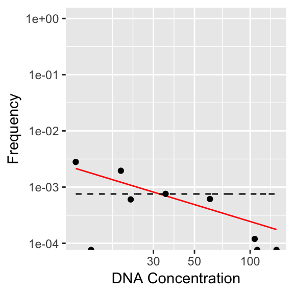

```r
set.seed(100)
plot_frequency(mock_ps, taxa_names(mock_ps)[sample(which(contam.freq$contaminant),1)], conc="DNA_conc")
```

Next, we use the contam.freq$contaminant result along with the prune_taxa phyloseq function to create a phyloseq object without the suspected contaminants.

```r
# create phyloseq object with contaminant ASVs removed
ps.noncontam.freq <- prune_taxa(!contam.freq$contaminant, mock_ps)
```

We can also use this approach to create a phyloseq object of just contaminant ASVs so that they can be inspected more closely/confirmed as contaminants.

```r
# create a phyloseq object with only contaminant ASVs
ps.contam.freq <- prune_taxa(contam.freq$contaminant, mock_ps)
```

Since we have a mock microbial dilution series, we can evaluate how well the contaminant removal worked by identifying the percentage of contaminant ASVs that were successfully removed.

```r
# Identify the percent of contaminants identified
ps_removed_prop <- prune_taxa(contam.freq$contaminant, mock_ps_norm)

# limit ps_norm_exp to dilution series samples (remove blank)
ps_norm_exp <- prune_samples(sample_names(ps_norm_exp) %in% sample_names(ps_removed_prop), ps_norm_exp)

# Print the percent of contaminant ASVs that were removed
print(sample_sums(ps_removed_prop)/(100-sample_sums(ps_norm_exp)) * 100)
```

```
## D0 D1 D2 D3 D4 D5 D6 D7 D8
## 25 60 25 37 20 19 11 17 14
```

```r
# Identify the percentage of contaminant still remaining in the dataset
# normalize the post-decontam phyloseq object to 100
ps.noncontam.freq.norm <- transform_sample_counts(ps.noncontam.freq,function(x) 100* x/sum(x))
# remove expected ASVs
ps_rem_contam <- prune_taxa(mock_taxa,ps.noncontam.freq.norm)
# print the percent of contaminants remaining after decontam
sample_sums(ps_rem_contam)
```

```
##  D0  D1  D2  D3  D4  D5  D6  D7  D8
## 100 100  99  97  90  76  38  49  22
```

We can also check that none of the expected ASVs were removed.

```r
# identify if expected ASVs are present in the contaminant ASVs
intersect(taxa_names(contam.freq), taxa_names(mock_ps))
```

```
## character(0)
```

We repeat this on various levels of the threshold parameter to identify the ideal one to use on our data set. To do this, we create a function called **testIsContam**

```r
# Create a function to evaluate the performance of decontam at different thresholds
testIsContam <-  function(physeq, thr, mock_taxa){
  # create normalized phyloseq object
    physeq_norm <- transform_sample_counts(physeq,function(x) 100* x/sum(x))
  # extract out original normalized otu table
    original_otus <- as.matrix(as.data.frame(physeq@otu_table))
  # identify the orginal proportion of contaminants
    contaminants_original <- rowSums(original_otus[,!colnames(original_otus) %in% mock_taxa])
  # identify the orginal proportion of mock community ASVs
    mock_original <- rowSums(original_otus[,colnames(original_otus) %in% mock_taxa])

  # apply decontam to the orginal phyloseq object
  contam.freq <- isContaminant(physeq, method="frequency", threshold=thr, conc="DNA_conc")
  # create physloseq object without contaminants
  physeq.noncontam.freq <- prune_taxa(!contam.freq$contaminant, physeq)
  # normalize the post-decontam phyloseq object to 100
  physeq.noncontam.freq.norm <- transform_sample_counts(physeq.noncontam.freq,function(x) 100* x/sum(x))

  # subset out the otu table of recovered otus (otus that are kept)
  recovered_otus <- as.matrix(as.data.frame(physeq.noncontam.freq@otu_table))

  # create a subset of removed otus for evaluation
  removed_otus <- as.matrix(as.data.frame(physeq@otu_table))
  removed_otus <- removed_otus[,!colnames(removed_otus) %in% colnames(recovered_otus)]

   # Summarize results
    ## proportion of contaminants removed (of all total contaminant ASVs)
    contaminants_removed = (rowSums(removed_otus[,!colnames(removed_otus) %in% mock_taxa])/ contaminants_original) * 100
    ## proportion of mock removed (of all total mock ASVs)
    mock_ASVs_removed = (rowSums(removed_otus[,colnames(removed_otus) %in% mock_taxa])/ mock_original) * 100
  ## total amount of contaminants remaining in ne
  contaminants_remaining =  rowSums(recovered_otus[,!colnames(recovered_otus) %in% mock_taxa])
  # calculate alpha diverity (on non-normalized decontam data) and summary of relative abundances (on normalized decontam data)
  diversity <- estimate_richness(physeq.noncontam.freq, measures = c('Observed','Shannon','InvSimpson'))
  rel_abundance <- as.data.frame(physeq.noncontam.freq.norm@otu_table)
  mock_abundance <- rel_abundance[, colnames(rel_abundance) %in% mock_taxa]
  total_mock_abundance <- rowSums(mock_abundance)
  con_abundance <- rowSums(rel_abundance[,!colnames(rel_abundance) %in% mock_taxa])

  # plot results
  compositionPlot <- expCompBarPlot(physeq.noncontam.freq, mock_taxa,  paste0('Decontam frequency, thr =', thr))

  # Calculate classifications

  #  % of mock community ASVs correctly classified as mock community ASVs
  true_neg <- rowSums(recovered_otus[,colnames(recovered_otus) %in% mock_taxa])
  # % of mock community incorrectly classified as mock community ASVs
  false_neg <- rowSums(recovered_otus[,!colnames(recovered_otus) %in% mock_taxa])
  #  identify non-mock community ASVs correctly classified as not belonging to mock   community
  true_pos <- rowSums(removed_otus[,!colnames(removed_otus) %in% mock_taxa])
  #  identify mock community ASVs incorrectly classified as not belonging to mock   community
  false_pos <- rowSums(removed_otus[,colnames(removed_otus) %in% mock_taxa])

  sensitivity <- true_pos/(true_pos + false_neg)
  specificty <- true_neg/(true_neg + false_pos)
  accuracy <- (true_pos + true_neg) / (false_pos + true_pos + false_neg + true_neg)
  prevalence <- (true_pos + false_neg) / (false_pos + true_pos + false_neg + true_neg)

# Plot classifications per sample (Figure 5A)
asv_profile <- rbind(false_neg,false_pos,true_neg,true_pos)
colnames(asv_profile) <- c('D0', 'D1','D2','D3', 'D4', 'D5', 'D6', 'D7', 'D8')

long_asv_profile <- melt(data = asv_profile,
                 id.vars = rownames(),
                 variable.name = colnames(),
                 value.name = "Abundance"
                )

# Create color palette
customPalette <- c('#969696','#bdbdbd','#1B9E77', '#D95F02')

  classificationPlot <- ggplot(long_asv_profile, aes(x = Var2, y = Abundance)) +
    geom_col(aes(fill = Var1), width = 0.7, position = position_fill())  +
    scale_fill_manual(values=customPalette) + theme(text = element_text(size=12)) +
    labs(x = "Sample", y = 'Proportion of Reads') +
      ggtitle(paste0('Sequence classification for \n  Decontam frequency, thr = ', thr)) +
      theme(legend.position = "right", legend.title = element_text(size = 12),
        axis.text = element_text(size = 12),
        axis.title = element_text(size = 16),
        plot.title = element_text(size = 16))
  # plot figures
  grid.arrange(compositionPlot, classificationPlot, ncol = 2)
  # return results

  results <- cbind(contaminants_removed, mock_ASVs_removed,con_abundance, total_mock_abundance, diversity, mock_abundance,sensitivity , specificty, accuracy, prevalence, true_pos, true_neg, false_pos, false_neg)
  results <- results %>%
    mutate(method = paste0('Decontam frequency, thr =', thr)) %>%
    mutate(sample_names = rownames(results))
  # return results
  return(results)

}

# Create function to plot bar plots with contaminants in grey scale and expected mock microbial sequences in color

 expCompBarPlot <- function(physeq, exp_taxa, title){
   ## physeq - phyloseq object that will be plotted
   ## exp_taxa - taxa that are expected to be in the mock community
   ## title - title for plot
#set up data_table
  data_table <- as.data.frame(t(physeq@otu_table))

  data_table$reference = FALSE
  data_table$reference[rownames(data_table) %in% exp_taxa] = TRUE
  sample_names <- sample_names(physeq)
  data_table$id <- paste0('ASV_', 1:nrow(data_table))
  dilution_labels <- sample_data(physeq)$Dilutions

  set.seed(444)

# define the colors to use for reference and non-reference OTUs/ASVs
  ref_colors <- brewer.pal(sum(data_table$reference), "Paired")
  other_colors <- sample(grey.colors(5, start = 0.5, end = 0.9), sum(!data_table$reference), replace = TRUE)

# add a color variable to the data table
  data_table$color <- rep(NA, nrow(data_table))
  data_table$color[data_table$reference] <- ref_colors
  data_table$color[!data_table$reference] <- other_colors

# reshape the data table into a ggplot-friendly format, by gathering samples into a single column called "count"

  color_gg <- data_table %>% select(id, sample_names, color) %>% gather("sample", "count", sample_names)
  legend_color <- c(bright = ref_colors[2], dull = other_colors[2])
  data_gg <- data_table %>% gather("sample", "count", sample_names)

  data_gg <- inner_join(data_gg,color_gg)

# create the composition bar plot
  comp_bar <- ggplot(data_gg, aes(x = sample, y = count)) +
    geom_col(aes(fill = color, group = reference, alpha = ifelse(reference, "bright", "dull")), width = 0.7, position = position_fill()) +
    scale_fill_identity(guide = FALSE) +
    scale_alpha_manual(name = "Sequence type",
                     labels = c("expected", "other"),
                     values = c(bright = 1, dull = 1),
                     guide = guide_legend(override.aes = list(fill = c(ref_colors[4], "#AEAEAE")),
                                          keywidth = NULL, keyheight = NULL)) +
    labs(title = title, x = "Sample", y = "Relative Abundance") +
    theme(legend.position = "right", legend.title = element_text(size = 10),
        axis.text = element_text(size = 10),
        axis.title = element_text(size = 12),
        plot.title = element_text(size = 12))
  comp_bar
 }

# create a function to write out summary table
summary_table <- function(results, thr){
    caption_text = paste0('Decontam frequency method, threshold = ', thr, ' summary')
    drop_col <- c('true_neg','true_pos','false_neg','false_pos','method')
    results <- results %>% select(-one_of(drop_col))
  kable(t(results), digits = 2, caption = caption_text) %>%
  kable_styling(bootstrap_options = c("striped", "hover"), full_width = F) %>%
    group_rows("Proportion Removed", 1,2) %>%
    group_rows("Percent Remaining after Contaminant Removal", 3,4) %>%
    group_rows("Diversity Estimates after Contaminant Removal", 5,7) %>%
  group_rows("Mock Abundances after Contaminant Removal", 8,16) %>%
  group_rows("Classification Performance", 17,20)

}
```

# Print Figures

```r
results_decontam_0_1 <- testIsContam(mock_ps,0.1, mock_taxa)
```

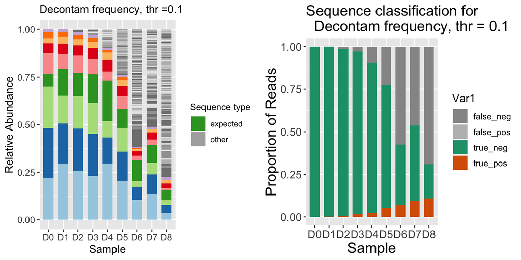

```r
results_decontam_0_2 <- testIsContam(mock_ps,0.2, mock_taxa)
```

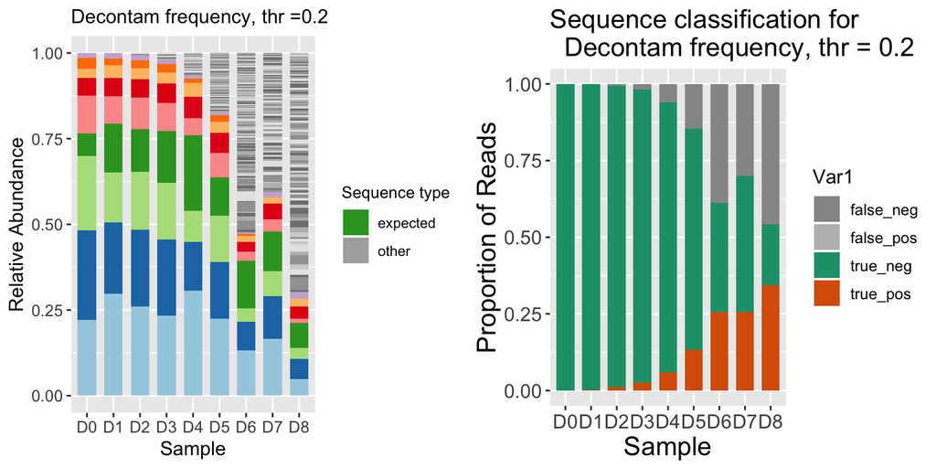

```r
results_decontam_0_3 <- testIsContam(mock_ps,0.3, mock_taxa)
```

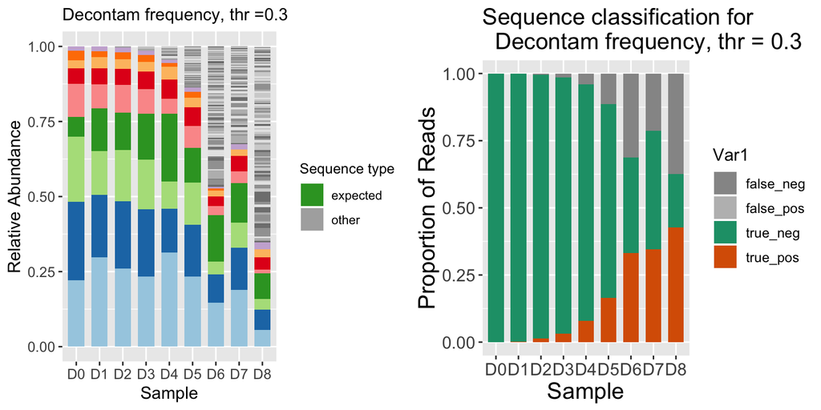

```r
results_decontam_0_4 <- testIsContam(mock_ps,0.4, mock_taxa)
```

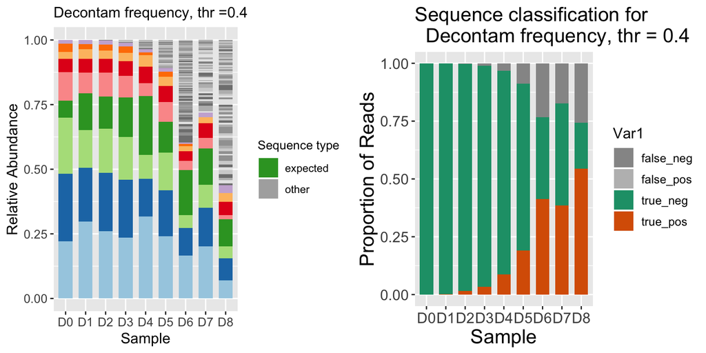

```r
results_decontam_0_5 <- testIsContam(mock_ps,0.5, mock_taxa)
```

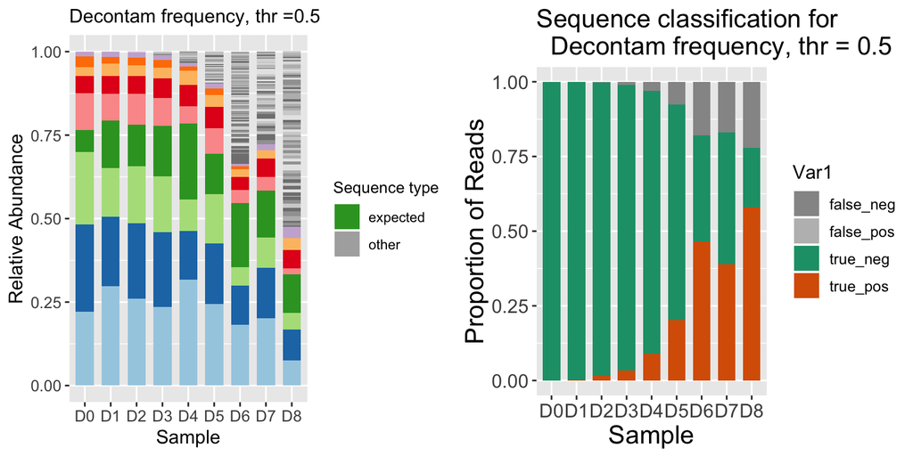

# Display tables

```r
summary_table(results_decontam_0_1, 0.1)
```

Decontam frequency method, threshold = 0.1 summary

| **Proportion Removed** |  |  |  |  |  |  |  |  |  |
| --- | --- | --- | --- | --- | --- | --- | --- | --- | --- |
| contaminants_removed | 25 | 60 | 25 | 37 | 20 | 19 | 11 | 17 | 14 |
| mock_ASVs_removed | 0 | 0 | 0 | 0 | 0 | 0 | 0 | 0 | 0 |
| **Percent Remaining after Contaminant Removal** |  |  |  |  |  |  |  |  |  |
| con_abundance | 0.037 | 0.056 | 1.352 | 2.845 | 9.845 | 23.793 | 61.807 | 51.138 | 77.601 |
| total_mock_abundance | 100 | 100 | 99 | 97 | 90 | 76 | 38 | 49 | 22 |
| **Diversity Estimates after Contaminant Removal** |  |  |  |  |  |  |  |  |  |
| Observed | 17 | 16 | 91 | 152 | 241 | 288 | 354 | 129 | 176 |
| Shannon | 1.9 | 1.9 | 2.0 | 2.1 | 2.4 | 3.2 | 4.4 | 3.9 | 4.7 |
| InvSimpson | 5.4 | 5.4 | 5.8 | 6.1 | 6.0 | 10.0 | 24.5 | 20.6 | 63.1 |
| **Mock Abundances after Contaminant Removal** |  |  |  |  |  |  |  |  |  |
| ASV_1 | 22.1 | 29.7 | 25.8 | 23.1 | 29.6 | 20.5 | 10.5 | 13.6 | 3.6 |
| ASV_2 | 26.0 | 20.9 | 22.2 | 22.1 | 13.7 | 15.3 | 6.7 | 10.2 | 4.3 |
| ASV_3 | 21.7 | 14.5 | 16.9 | 16.3 | 8.6 | 12.4 | 3.1 | 6.0 | 2.4 |
| ASV_4 | 6.6 | 14.2 | 12.3 | 15.0 | 21.3 | 10.2 | 11.1 | 9.5 | 5.4 |
| ASV_5 | 11.06 | 7.93 | 9.10 | 8.13 | 4.75 | 6.53 | 2.21 | 2.79 | 0.88 |
| ASV_6 | 5.1 | 5.3 | 5.3 | 5.7 | 6.0 | 5.4 | 2.3 | 3.8 | 2.6 |
| ASV_7 | 2.7 | 3.7 | 3.2 | 3.1 | 4.0 | 2.9 | 1.3 | 1.6 | 1.7 |
| ASV_8 | 3.13 | 2.06 | 2.33 | 2.36 | 1.13 | 1.70 | 0.52 | 0.00 | 0.00 |
| ASV_10 | 1.44 | 1.54 | 1.50 | 1.38 | 1.06 | 1.24 | 0.38 | 1.28 | 1.55 |
| **Classification Performance** |  |  |  |  |  |  |  |  |  |
| sensitivity | 0.25 | 0.60 | 0.25 | 0.37 | 0.20 | 0.19 | 0.11 | 0.17 | 0.14 |
| specificty | 1 | 1 | 1 | 1 | 1 | 1 | 1 | 1 | 1 |
| accuracy | 1.00 | 1.00 | 0.99 | 0.97 | 0.90 | 0.77 | 0.43 | 0.54 | 0.31 |
| prevalence | 0.0005 | 0.0014 | 0.0180 | 0.0445 | 0.1196 | 0.2786 | 0.6448 | 0.5577 | 0.8006 |
| sample_names | D0 | D1 | D2 | D3 | D4 | D5 | D6 | D7 | D8 |

```r
summary_table(results_decontam_0_2, 0.2)
```

Decontam frequency method, threshold = 0.2 summary

| **Proportion Removed** |  |  |  |  |  |  |  |  |  |
| --- | --- | --- | --- | --- | --- | --- | --- | --- | --- |
| contaminants_removed | 48 | 90 | 67 | 59 | 50 | 48 | 40 | 46 | 43 |
| mock_ASVs_removed | 0 | 0 | 0 | 0 | 0 | 0 | 0 | 0 | 0 |
| **Percent Remaining after Contaminant Removal** |  |  |  |  |  |  |  |  |  |
| con_abundance | 0.026 | 0.013 | 0.594 | 1.881 | 6.360 | 16.845 | 52.258 | 40.506 | 69.623 |
| total_mock_abundance | 100 | 100 | 99 | 98 | 94 | 83 | 48 | 59 | 30 |
| **Diversity Estimates after Contaminant Removal** |  |  |  |  |  |  |  |  |  |
| Observed | 14 | 10 | 58 | 120 | 199 | 244 | 312 | 103 | 148 |
| Shannon | 1.9 | 1.9 | 1.9 | 2.0 | 2.2 | 2.9 | 4.2 | 3.5 | 4.5 |
| InvSimpson | 5.4 | 5.4 | 5.7 | 6.0 | 5.6 | 8.4 | 20.1 | 14.6 | 51.9 |
| **Mock Abundances after Contaminant Removal** |  |  |  |  |  |  |  |  |  |
| ASV_1 | 22.1 | 29.7 | 26.0 | 23.3 | 30.7 | 22.4 | 13.1 | 16.6 | 4.9 |
| ASV_2 | 26.1 | 21.0 | 22.4 | 22.3 | 14.2 | 16.7 | 8.4 | 12.5 | 5.9 |
| ASV_3 | 21.7 | 14.5 | 17.0 | 16.5 | 9.0 | 13.5 | 3.9 | 7.3 | 3.2 |
| ASV_4 | 6.6 | 14.2 | 12.4 | 15.2 | 22.1 | 11.1 | 13.8 | 11.6 | 7.3 |
| ASV_5 | 11.1 | 7.9 | 9.2 | 8.2 | 4.9 | 7.1 | 2.8 | 3.4 | 1.2 |
| ASV_6 | 5.1 | 5.4 | 5.3 | 5.7 | 6.2 | 5.9 | 2.9 | 4.6 | 3.5 |
| ASV_7 | 2.7 | 3.7 | 3.2 | 3.2 | 4.2 | 3.2 | 1.7 | 1.9 | 2.3 |
| ASV_8 | 3.13 | 2.06 | 2.34 | 2.38 | 1.17 | 1.86 | 0.65 | 0.00 | 0.00 |
| ASV_10 | 1.44 | 1.54 | 1.51 | 1.39 | 1.10 | 1.35 | 0.48 | 1.56 | 2.10 |
| **Classification Performance** |  |  |  |  |  |  |  |  |  |
| sensitivity | 0.48 | 0.90 | 0.67 | 0.59 | 0.50 | 0.48 | 0.40 | 0.46 | 0.43 |
| specificty | 1 | 1 | 1 | 1 | 1 | 1 | 1 | 1 | 1 |
| accuracy | 1.00 | 1.00 | 0.99 | 0.98 | 0.94 | 0.85 | 0.61 | 0.70 | 0.54 |
| prevalence | 0.0005 | 0.0014 | 0.0180 | 0.0445 | 0.1196 | 0.2786 | 0.6448 | 0.5577 | 0.8006 |
| sample_names | D0 | D1 | D2 | D3 | D4 | D5 | D6 | D7 | D8 |

```r
summary_table(results_decontam_0_3,0.3)
```

Decontam frequency method, threshold = 0.3 summary

| **Proportion Removed** |  |  |  |  |  |  |  |  |  |
| --- | --- | --- | --- | --- | --- | --- | --- | --- | --- |
| contaminants_removed | 48 | 90 | 80 | 69 | 66 | 59 | 52 | 62 | 53 |
| mock_ASVs_removed | 0 | 0 | 0 | 0 | 0 | 0 | 0 | 0 | 0 |
| **Percent Remaining after Contaminant Removal** |  |  |  |  |  |  |  |  |  |
| con_abundance | 0.026 | 0.013 | 0.358 | 1.416 | 4.415 | 13.680 | 46.814 | 32.473 | 65.222 |
| total_mock_abundance | 100 | 100 | 100 | 99 | 96 | 86 | 53 | 68 | 35 |
| **Diversity Estimates after Contaminant Removal** |  |  |  |  |  |  |  |  |  |
| Observed | 14 | 10 | 40 | 94 | 162 | 212 | 277 | 81 | 129 |
| Shannon | 1.9 | 1.9 | 1.9 | 2.0 | 2.1 | 2.8 | 4.0 | 3.2 | 4.3 |
| InvSimpson | 5.4 | 5.4 | 5.7 | 6.0 | 5.3 | 7.8 | 16.5 | 11.5 | 41.9 |
| **Mock Abundances after Contaminant Removal** |  |  |  |  |  |  |  |  |  |
| ASV_1 | 22.1 | 29.7 | 26.1 | 23.4 | 31.4 | 23.3 | 14.6 | 18.8 | 5.6 |
| ASV_2 | 26.1 | 21.0 | 22.4 | 22.4 | 14.5 | 17.3 | 9.4 | 14.2 | 6.7 |
| ASV_3 | 21.7 | 14.5 | 17.1 | 16.5 | 9.2 | 14.0 | 4.4 | 8.3 | 3.7 |
| ASV_4 | 6.6 | 14.2 | 12.5 | 15.2 | 22.6 | 11.6 | 15.4 | 13.1 | 8.4 |
| ASV_5 | 11.1 | 7.9 | 9.2 | 8.3 | 5.0 | 7.4 | 3.1 | 3.9 | 1.4 |
| ASV_6 | 5.1 | 5.4 | 5.4 | 5.8 | 6.3 | 6.1 | 3.2 | 5.3 | 4.0 |
| ASV_7 | 2.7 | 3.7 | 3.2 | 3.2 | 4.3 | 3.3 | 1.9 | 2.2 | 2.7 |
| ASV_8 | 3.13 | 2.06 | 2.35 | 2.39 | 1.20 | 1.93 | 0.73 | 0.00 | 0.00 |
| ASV_10 | 1.44 | 1.54 | 1.51 | 1.40 | 1.12 | 1.40 | 0.54 | 1.77 | 2.40 |
| **Classification Performance** |  |  |  |  |  |  |  |  |  |
| sensitivity | 0.48 | 0.90 | 0.80 | 0.69 | 0.66 | 0.59 | 0.52 | 0.62 | 0.53 |
| specificty | 1 | 1 | 1 | 1 | 1 | 1 | 1 | 1 | 1 |
| accuracy | 1.00 | 1.00 | 1.00 | 0.99 | 0.96 | 0.89 | 0.69 | 0.79 | 0.63 |
| prevalence | 0.0005 | 0.0014 | 0.0180 | 0.0445 | 0.1196 | 0.2786 | 0.6448 | 0.5577 | 0.8006 |
| sample_names | D0 | D1 | D2 | D3 | D4 | D5 | D6 | D7 | D8 |

```r
summary_table(results_decontam_0_4, 0.4)
```

Decontam frequency method, threshold = 0.4 summary

| **Proportion Removed** |  |  |  |  |  |  |  |  |  |
| --- | --- | --- | --- | --- | --- | --- | --- | --- | --- |
| contaminants_removed | 88 | 90 | 89 | 75 | 73 | 68 | 64 | 69 | 68 |
| mock_ASVs_removed | 0 | 0 | 0 | 0 | 0 | 0 | 0 | 0 | 0 |
| **Percent Remaining after Contaminant Removal** |  |  |  |  |  |  |  |  |  |
| con_abundance | 0.006 | 0.013 | 0.202 | 1.143 | 3.583 | 10.860 | 39.579 | 28.061 | 56.266 |
| total_mock_abundance | 100 | 100 | 100 | 99 | 96 | 89 | 60 | 72 | 44 |
| **Diversity Estimates after Contaminant Removal** |  |  |  |  |  |  |  |  |  |
| Observed | 13 | 10 | 36 | 75 | 136 | 178 | 241 | 71 | 102 |
| Shannon | 1.9 | 1.9 | 1.9 | 2.0 | 2.0 | 2.6 | 3.7 | 3.0 | 4.0 |
| InvSimpson | 5.4 | 5.4 | 5.7 | 5.9 | 5.2 | 7.3 | 13.0 | 10.2 | 29.0 |
| **Mock Abundances after Contaminant Removal** |  |  |  |  |  |  |  |  |  |
| ASV_1 | 22 | 30 | 26 | 23 | 32 | 24 | 17 | 20 | 7 |
| ASV_2 | 26.1 | 21.0 | 22.4 | 22.5 | 14.6 | 17.9 | 10.6 | 15.1 | 8.5 |
| ASV_3 | 21.7 | 14.5 | 17.1 | 16.6 | 9.2 | 14.5 | 5.0 | 8.9 | 4.6 |
| ASV_4 | 6.6 | 14.2 | 12.5 | 15.3 | 22.8 | 11.9 | 17.5 | 14.0 | 10.5 |
| ASV_5 | 11.1 | 7.9 | 9.2 | 8.3 | 5.1 | 7.6 | 3.5 | 4.1 | 1.7 |
| ASV_6 | 5.1 | 5.4 | 5.4 | 5.8 | 6.4 | 6.3 | 3.7 | 5.6 | 5.0 |
| ASV_7 | 2.7 | 3.7 | 3.2 | 3.2 | 4.3 | 3.4 | 2.1 | 2.3 | 3.4 |
| ASV_8 | 3.13 | 2.06 | 2.35 | 2.40 | 1.21 | 1.99 | 0.83 | 0.00 | 0.00 |
| ASV_10 | 1.44 | 1.54 | 1.52 | 1.40 | 1.13 | 1.45 | 0.61 | 1.89 | 3.02 |
| **Classification Performance** |  |  |  |  |  |  |  |  |  |
| sensitivity | 0.88 | 0.90 | 0.89 | 0.75 | 0.73 | 0.68 | 0.64 | 0.69 | 0.68 |
| specificty | 1 | 1 | 1 | 1 | 1 | 1 | 1 | 1 | 1 |
| accuracy | 1.00 | 1.00 | 1.00 | 0.99 | 0.97 | 0.91 | 0.77 | 0.83 | 0.74 |
| prevalence | 0.0005 | 0.0014 | 0.0180 | 0.0445 | 0.1196 | 0.2786 | 0.6448 | 0.5577 | 0.8006 |
| sample_names | D0 | D1 | D2 | D3 | D4 | D5 | D6 | D7 | D8 |

```r
summary_table(results_decontam_0_5,0.5)
```

Decontam frequency method, threshold = 0.5 summary

| **Proportion Removed** |  |  |  |  |  |  |  |  |  |
| --- | --- | --- | --- | --- | --- | --- | --- | --- | --- |
| contaminants_removed | 88 | 90 | 90 | 77 | 75 | 73 | 72 | 70 | 72 |
| mock_ASVs_removed | 0 | 0 | 0 | 0 | 0 | 0 | 0 | 0 | 0 |
| **Percent Remaining after Contaminant Removal** |  |  |  |  |  |  |  |  |  |
| con_abundance | 0.006 | 0.013 | 0.188 | 1.083 | 3.319 | 9.525 | 33.577 | 27.689 | 52.506 |
| total_mock_abundance | 100 | 100 | 100 | 99 | 97 | 90 | 66 | 72 | 47 |
| **Diversity Estimates after Contaminant Removal** |  |  |  |  |  |  |  |  |  |
| Observed | 13 | 10 | 35 | 72 | 126 | 160 | 215 | 69 | 94 |
| Shannon | 1.9 | 1.9 | 1.9 | 2.0 | 2.0 | 2.5 | 3.5 | 3.0 | 3.9 |
| InvSimpson | 5.4 | 5.4 | 5.7 | 5.9 | 5.2 | 7.1 | 10.8 | 10.1 | 25.2 |
| **Mock Abundances after Contaminant Removal** |  |  |  |  |  |  |  |  |  |
| ASV_1 | 22.1 | 29.7 | 26.1 | 23.5 | 31.7 | 24.4 | 18.3 | 20.2 | 7.6 |
| ASV_2 | 26.1 | 21.0 | 22.4 | 22.5 | 14.7 | 18.1 | 11.7 | 15.2 | 9.2 |
| ASV_3 | 21.7 | 14.5 | 17.1 | 16.6 | 9.3 | 14.7 | 5.5 | 8.9 | 5.0 |
| ASV_4 | 6.6 | 14.2 | 12.5 | 15.3 | 22.9 | 12.1 | 19.3 | 14.0 | 11.4 |
| ASV_5 | 11.1 | 7.9 | 9.2 | 8.3 | 5.1 | 7.8 | 3.8 | 4.1 | 1.9 |
| ASV_6 | 5.1 | 5.4 | 5.4 | 5.8 | 6.4 | 6.4 | 4.0 | 5.6 | 5.5 |
| ASV_7 | 2.7 | 3.7 | 3.2 | 3.2 | 4.3 | 3.5 | 2.3 | 2.3 | 3.6 |
| ASV_8 | 3.13 | 2.06 | 2.35 | 2.40 | 1.21 | 2.02 | 0.91 | 0.00 | 0.00 |
| ASV_10 | 1.44 | 1.54 | 1.52 | 1.40 | 1.14 | 1.47 | 0.67 | 1.90 | 3.28 |
| **Classification Performance** |  |  |  |  |  |  |  |  |  |
| sensitivity | 0.88 | 0.90 | 0.90 | 0.77 | 0.75 | 0.73 | 0.72 | 0.70 | 0.72 |
| specificty | 1 | 1 | 1 | 1 | 1 | 1 | 1 | 1 | 1 |
| accuracy | 1.00 | 1.00 | 1.00 | 0.99 | 0.97 | 0.92 | 0.82 | 0.83 | 0.78 |
| prevalence | 0.0005 | 0.0014 | 0.0180 | 0.0445 | 0.1196 | 0.2786 | 0.6448 | 0.5577 | 0.8006 |
| sample_names | D0 | D1 | D2 | D3 | D4 | D5 | D6 | D7 | D8 |

Using a threshold of 0.5 is reasonable since it removed many of the contaminant ASVs but did not remove any of the expected ASVs.

```r
contam.freq <- isContaminant(mock_ps, method="frequency", threshold=0.5, conc="DNA_conc")
ps.noncontam.freq <- prune_taxa(!contam.freq$contaminant, mock_ps)
```

We plot the stacked bar plot of the contaminant corrected microbiome profiles for the mock microbial community dilution series. There are still some contaminants, but they are greatly reduced.

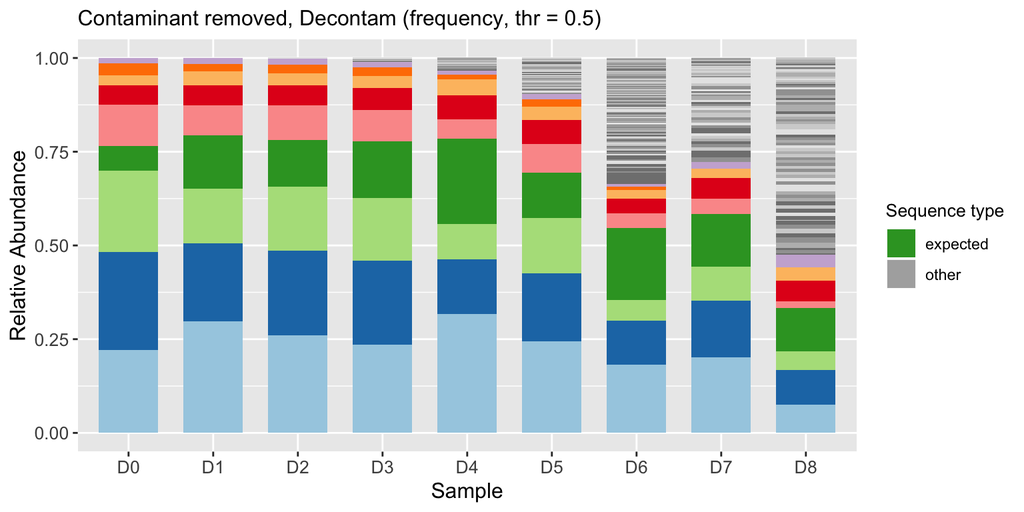

```r
expCompBarPlot(ps.noncontam.freq, mock_taxa, 'Contaminant removed, Decontam (frequency, thr = 0.5)')
```

This work demonstrates using the frequency method implemented in decontam for identifying and removing contaminants from a 16S rRNA gene sequencing experiment. We were able to evaluate the performance of this method since we used a dilution series of a mock microbial community, where the expected composition of the samples are known. Decontam is one analytical method for identifying and removing contaminants from 16S rRNA gene sequencing data. We also evaluated using SourceTracker, which is documented here.

```r
vars_to_keep <- ls(pattern = 'results')
vars_to_rm <- ls()
vars_to_rm <-vars_to_rm[!vars_to_rm %in% vars_to_keep]
rm(list = vars_to_rm)
rm(vars_to_rm, vars_to_keep)
```

```r
save.image('results_decontam.RData')
```